# Evaluation of the CAZyme classifiers: dbCAN, CUPP and eCAMI

## 5.4 Evaluation of multi-label CAZy family classification performance

CAZy annotates proteins in a domain-wise manner. Consequently, a single protein may be assigned to multiple CAZy families. The ability of a classifier to assign all the correct CAZy family annotations for a given protein when only evaluating the CAZy family classification performance per CAZy family, independently of all other CAZy classes.

The CAZy family multi-label classification performance is represented by the Rand Index (RI) and Adjusted Rand Index (ARI). The RI is a quantitive measure of similarity between two clusterings by considering all pairs of samples and counting pairs that are assigned in the same or different clusters in the predicted and true clusterings. In this case the two clusters are the predicted and groud truth CAZy family annotations. The raw RI score is then “adjusted for chance” into the ARI score using the following scheme:  
`ARI = (RI - Expected_RI) / (max(RI) - Expected_RI)`  
This produces a score between 1 and -1. A score of 1 is produced if all predicted and known CAZy family annotations are identical, 0 if completely random clustering of -1 if systematically incorrect clustering and the number of incorrect classifications of proteins is greater than would be expected from randomly annotating proteins with CAZy families.

Table 5.3: Rand Index of CAZyme classifier classification of CAZy family annotations

| Prediction_tool | Mean | Standard Deviation |
| --- | --- | --- |
| dbCAN | 0.9997 | 0.0011 |
| HMMER | 0.9996 | 0.0014 |
| DIAMOND | 0.9998 | 0.0010 |
| Hotpep | 0.9991 | 0.0023 |
| CUPP | 0.9995 | 0.0015 |
| eCAMI | 0.9994 | 0.0017 |

Table 5.4: Adjusted Rand Index of CAZyme classifier classification of CAZy family annotations

| Prediction_tool | Mean | Standard Deviation |
| --- | --- | --- |
| dbCAN | 0.9391 | 0.2359 |
| HMMER | 0.9250 | 0.2554 |
| DIAMOND | 0.9530 | 0.2105 |
| Hotpep | 0.8758 | 0.3083 |
| CUPP | 0.9098 | 0.2712 |
| eCAMI | 0.9077 | 0.2778 |

Multilabel classification raises when a single instance can be assinged to multiple classes. In this evaluation a single instance is a protein and the classes are CAZy families, a single CAZyme can be assigned to multiple CAZy families. This is important to take into consideration because the same approaches for statistical evaluation of binary classification provided a limited view of the performance of the classifiers when applied to multilabel classification.

Figures 5.15 and 5.16 present one-dimensional scatter plots of the Rand Index and Adjusted Rand Index for every protein in every test set, respectively, overlaying violin plots (true negative non-CAZyme classifications were excluded).

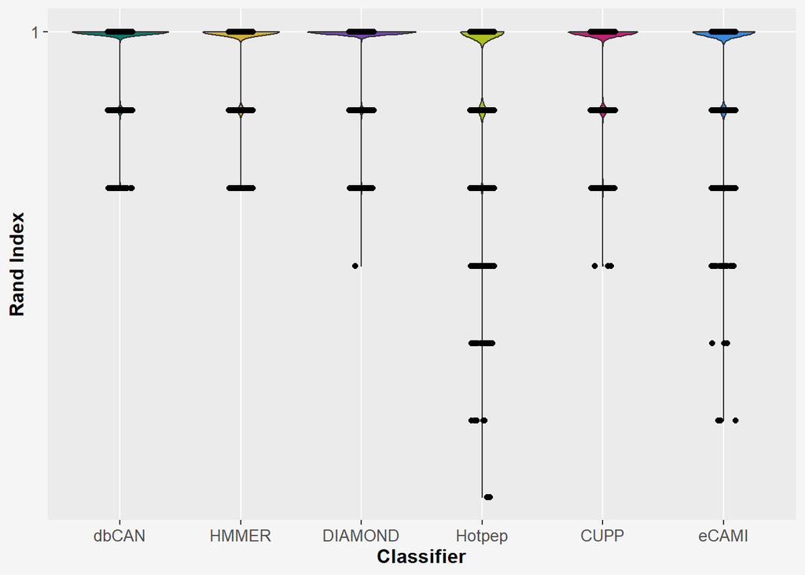

Figure 5.15: Violin plot of Rand Index (RI) of performance of the CAZyme classifiers to predict the multilabel classification of CAZy classes.

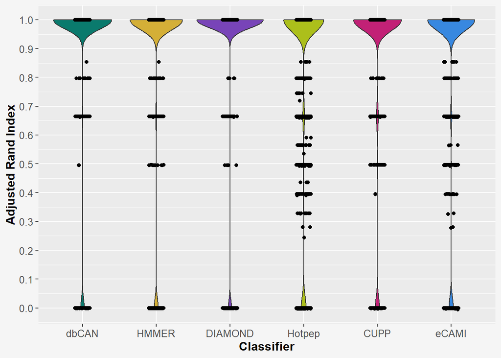

Figure 5.16: Violin plot of Adjusted Rand Index (ARI) of performance of the CAZyme classifiers to predict the multilabel classification of CAZy classes.

# 6 Performance per taxonomy group

The performance for a classifier per taxonomy group may vary. For this evaluation the test sets were separated into the taxonomy groups: - Bacteria - Eukaryote

The evaluation per classifier per taxonomy group, versus all test sets pooled together was evaluated.

## 6.1 Binary classification of CAZymes and non-CAZymes

Table 6.1 presents the mean plus and minus the standard deviation of the F1-score of each prediction tool for each taxonomy group, in order to represent the overall performance per taxonomy group for each CAZyme classifier.

Table 6.1: Overall performance of binary CAZyme/non-CAZyme classification by CAZy classifiers per taxonomy group

| Prediction_tool | Bacterial Mean | Bacterial Standard Deviation | Eukaryote Mean | Eukaryote Standard Deviation | All Mean | All Standard Deviation |
| --- | --- | --- | --- | --- | --- | --- |
| CUPP | 0.9217 | 0.0522 | 0.9103 | 0.0545 | 0.9167 | 0.0531 |
| dbCAN | 0.9434 | 0.0782 | 0.9385 | 0.0826 | 0.9412 | 0.0796 |
| DIAMOND | 0.9481 | 0.0919 | 0.9480 | 0.0908 | 0.9481 | 0.0907 |
| eCAMI | 0.9270 | 0.0763 | 0.8913 | 0.0960 | 0.9112 | 0.0868 |
| HMMER | 0.9210 | 0.0791 | 0.9425 | 0.0215 | 0.9305 | 0.0613 |
| Hotpep | 0.8898 | 0.0774 | 0.8817 | 0.1083 | 0.8862 | 0.0917 |

### 6.1.1 Specificity

Figure 6.1 demonstrates the specificity per test set in each taxonomic group, per CAZyme classifier, for the binary CAZyme/non-CAZyme classification of all proteins across all test sets.

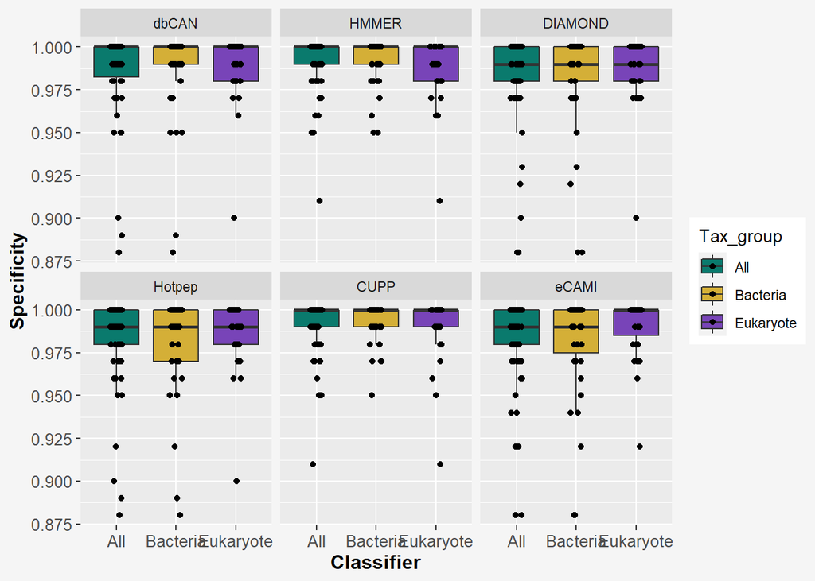

Figure 6.1: One dimensional scatter plot overlaying a box and whisker plot of the specificity of binary classification per CAZyme/non-CAZyme classifier per taxonomy group. Each point represents the score from one test set.

### 6.1.2 Sensitivity

Figure 6.2 demonstrates the sensitivity per test set in each taxonomic group, per CAZyme classifier, for the binary CAZyme/non-CAZyme classification of all proteins across all test sets.

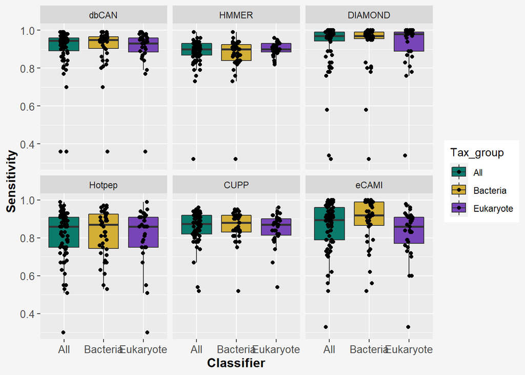

Figure 6.2: One dimensional scatter plot overlaying a box and whisker plot of the sensitivity of binary classification per CAZyme/non-CAZyme classifier per taxonomy group. Each point represents the score from one test set.

### 6.1.3 Percision

Figure 6.3 demonstrates the precision per test set in each taxonomic group, per CAZyme classifier, for the binary CAZyme/non-CAZyme classification of all proteins across all test sets.

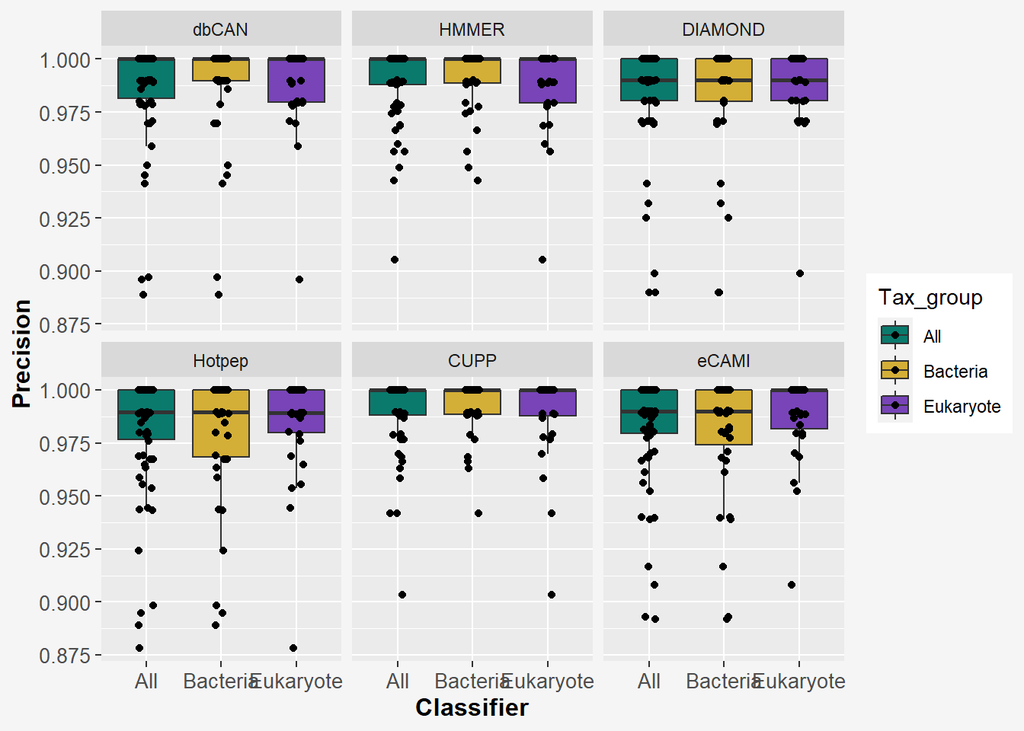

Figure 6.3: One dimensional scatter plot overlaying a box and whisker plot of the precision of binary classification per CAZyme/non-CAZyme classifier per taxonomy group. Each point represents the score from one test set.

### 6.1.4 F1-score

Figure 6.4 demonstrates the F1-score per test set in each taxonomic group, per CAZyme classifier, for the binary CAZyme/non-CAZyme classification of all proteins across all test sets.

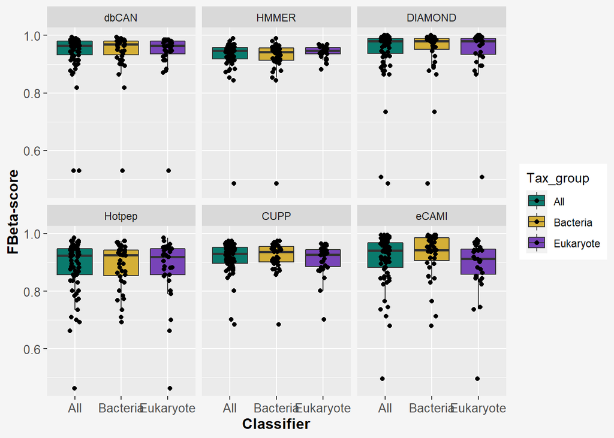

Figure 6.4: One dimensional scatter plot overlaying a box and whisker plot of the F1-score of binary classification per CAZyme/non-CAZyme classifier per taxonomy group. Each point represents the score from one test set.

### 6.1.5 Accuracy

Figure 6.5 demonstrates the accuracy per test set in each taxonomic group, per CAZyme classifier, for the binary CAZyme/non-CAZyme classification of all proteins across all test sets.

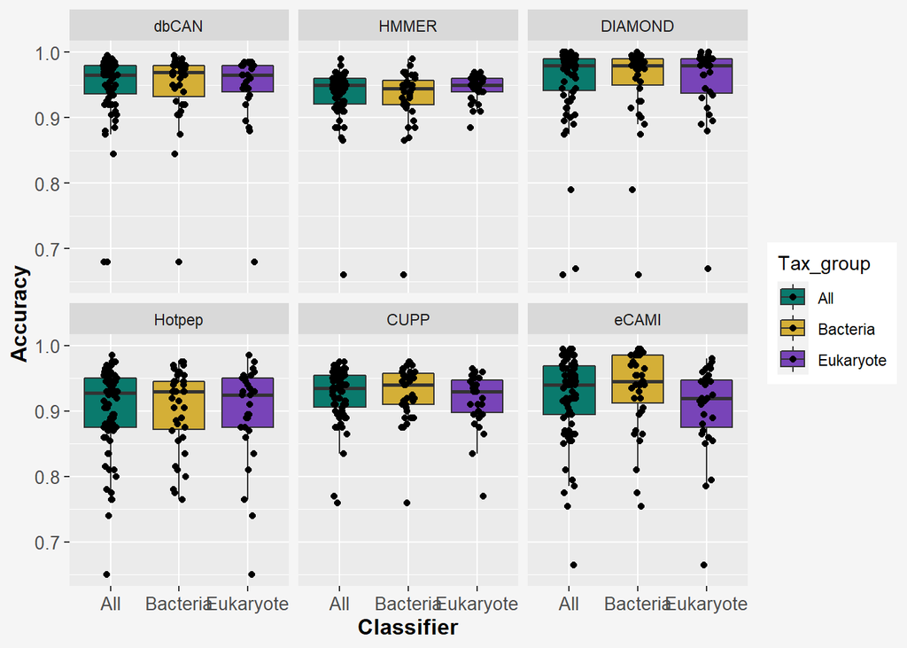

Figure 6.5: One dimensional scatter plot overlaying a box and whisker plot of the accuracy of binary classification per CAZyme/non-CAZyme classifier per taxonomy group. Each point represents the score from one test set.

## 6.2 CAZy class classification

To represent the overall CAZy class classification performance, and take into consideration of CAZy class multilabel classification, the RI was calculated for every protein in each taxonomy group per CAZy classifier. The mean and standard deviation of the calculated RI values are presented in table 6.2.

Table 6.2: Overall performance of CAZy class classification (represented by the Rand Index) by CAZy classifiers per taxonomy group

| Prediction_tool | Bacteria Mean | Bacteria Standard Deviation | Eukaryote Mean | Eukaryote Standard Deviation | All Mean | All Standard Deviation |
| --- | --- | --- | --- | --- | --- | --- |
| CUPP | 0.9615 | 0.1074 | 0.9637 | 0.1044 | 0.9625 | 0.1061 |
| dbCAN | 0.9802 | 0.0794 | 0.9781 | 0.0832 | 0.9793 | 0.0811 |
| DIAMOND | 0.9845 | 0.0711 | 0.9844 | 0.0710 | 0.9845 | 0.0711 |
| eCAMI | 0.9674 | 0.1008 | 0.9630 | 0.1064 | 0.9655 | 0.1034 |
| HMMER | 0.9725 | 0.0926 | 0.9750 | 0.0884 | 0.9736 | 0.0908 |
| Hotpep | 0.9495 | 0.1217 | 0.9533 | 0.1170 | 0.9512 | 0.1197 |

The ARI was also calculated in order to take into consideration chance, and the results are presented in table 6.3.

Table 6.3: Overall performance of CAZy class classification (represented by the Adjusted Rand Index) by CAZy classifiers per taxonomy group

| Prediction_tool | Bacteria Mean | Bacteria Standard Deviation | Eukaryote Mean | Eukaryote Standard Deviation | All Mean | All Standard Deviation |
| --- | --- | --- | --- | --- | --- | --- |
| CUPP | 0.9004 | 0.2829 | 0.9011 | 0.2880 | 0.9007 | 0.2852 |
| dbCAN | 0.9427 | 0.2304 | 0.9361 | 0.2426 | 0.9398 | 0.2359 |
| DIAMOND | 0.9546 | 0.2078 | 0.9543 | 0.2080 | 0.9545 | 0.2079 |
| eCAMI | 0.9140 | 0.2691 | 0.8958 | 0.3006 | 0.9060 | 0.2836 |
| HMMER | 0.9225 | 0.2622 | 0.9322 | 0.2425 | 0.9268 | 0.2537 |
| Hotpep | 0.8681 | 0.3222 | 0.8739 | 0.3201 | 0.8706 | 0.3212 |

## 6.3 CAZy family classification

To represent the overall CAZy family classification performance, and take into consideration of CAZy class multilabel classification, the RI was calculated for every protein in each taxonomy group per CAZy classifier. The mean and standard deviation of the calculated RI values are presented in table 6.4.

Table 6.4: Rand Index of CAZyme classifier classification of CAZy family annotations per taxonomt group

| Prediction_tool | Bacteria Mean | Bacteria Standard Deviation | Eukaryote Mean | Eukaryote Standard Deviation | All Mean | All Standard Deviation |
| --- | --- | --- | --- | --- | --- | --- |
| CUPP | 0.9994 | 0.0016 | 0.9995 | 0.0015 | 0.9995 | 0.0015 |
| dbCAN | 0.9997 | 0.0011 | 0.9997 | 0.0012 | 0.9997 | 0.0011 |
| DIAMOND | 0.9998 | 0.0010 | 0.9998 | 0.0010 | 0.9998 | 0.0010 |
| eCAMI | 0.9994 | 0.0018 | 0.9995 | 0.0015 | 0.9994 | 0.0017 |
| HMMER | 0.9996 | 0.0014 | 0.9996 | 0.0014 | 0.9996 | 0.0014 |
| Hotpep | 0.9990 | 0.0025 | 0.9993 | 0.0019 | 0.9991 | 0.0023 |

The ARI was also calculated in order to take into consideration chance, and the results are presented in table 6.5.

Table 6.5: Adjusted Rand Index of CAZyme classifier classification of CAZy family annotations per taxonomt group

| Prediction_tool | Bacteria Mean | Bacteria Standard Deviation | Eukaryote Mean | Eukaryote Standard Deviation | All Mean | All Standard Deviation |
| --- | --- | --- | --- | --- | --- | --- |
| CUPP | 0.9118 | 0.2654 | 0.9073 | 0.2782 | 0.9098 | 0.2712 |
| dbCAN | 0.9420 | 0.2307 | 0.9354 | 0.2422 | 0.9391 | 0.2359 |
| DIAMOND | 0.9529 | 0.2104 | 0.9531 | 0.2105 | 0.9530 | 0.2105 |
| eCAMI | 0.9148 | 0.2621 | 0.8988 | 0.2961 | 0.9077 | 0.2778 |
| HMMER | 0.9201 | 0.2647 | 0.9311 | 0.2430 | 0.9250 | 0.2554 |
| Hotpep | 0.8715 | 0.3087 | 0.8812 | 0.3077 | 0.8758 | 0.3083 |

# 7 Conclusions

Overall, all CAZyme classifiers showed strong performances at all three levels of CAZyme classification (CAZyme/non-CAZyme. CAZy class and CAZy family).

Performance was extremely strong for CAZyme classifiers for across all levels of CAZyme classification, performance in CAZyme classifiers varied most greatly for sensitivity.

In general, the CAZyme/non-CAZyme, CAZy class and CAZy family classifications were accurate for all CAZyme classifiers (i.e. when a classification is predicted it was frequently correct). however, the CAZyme classifiers do not predict a comprehensive CAZome. CAZyme classifiers performance differed most greatly by sensitivity, which indicated an non-comprehensive annotation of the CAZome, CAZy class members and CAZy family members.

Classifying Bacterial or Eukaryote had neglebialbe impact on the performance of the CAZyme classification at at every level of classification (CAZyme/non-CAZyme. CAZy class and CAZy family).